# Stevia Microbiota

Edna Chiang

July 26, 2018

# Take-Away Points

- There is little difference between High Fat, Saccharin, and Stevia samples.
- The majority of differences are between Low Fat and the other 3 treatments (all of which include a high fat diet)

# Description

This is a quick summary of the follow-up analyses to Sarah’s thesis that I’ve performed.  
A few differences between Sarah’s analysis and my analysis:

- I perform my analysis at the OTU-level (97% sequence similarity, akin to species-level)
- I included only individuals with both pre-treatment and post-treatment samples because I run a few paired tests and want to keep the samples consistent throughout all analyses. I removed 4 individuals, resulting in the following final sample count:

  | Treatment | N | Female | Male |
  | --- | --- | --- | --- |
  | High Fat | 9 | 4 | 5 |
  | Low Fat | 10 | 5 | 5 |
  | Saccharin | 9 | 5 | 4 |
  | Stevia | 8 | 4 | 4 |

# Phylum-Level Composition

The phyla are listed in order of highest overall relative abundance to lowest overall relative abundance. Phyla with a total relative abundance of < 0.01% were removed. Error bars represent the interquartile range.

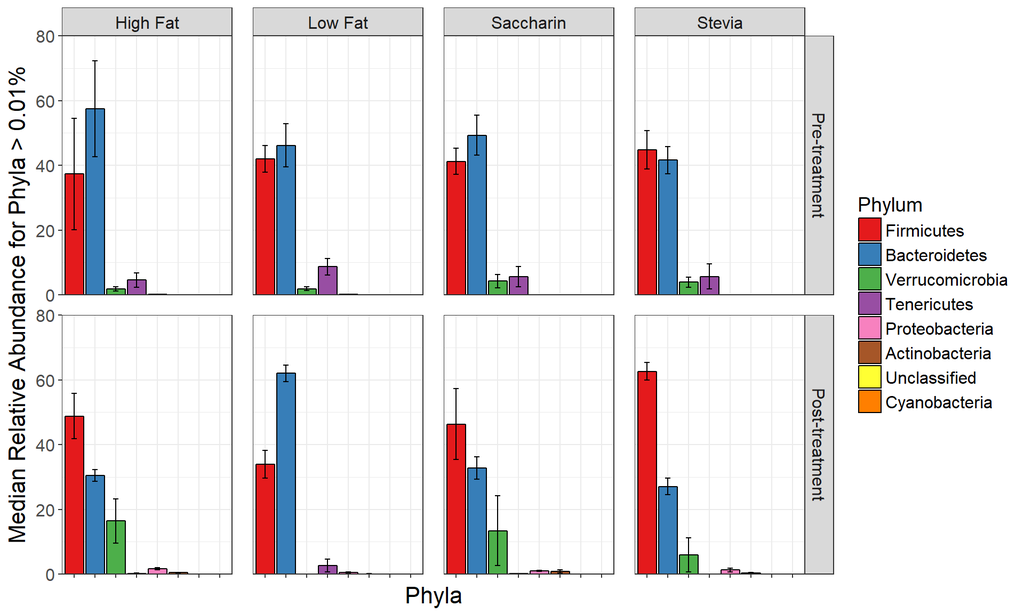

Visually (not statistically tested yet), there are shifts in Pre-treatment vs. Post-treatment.  
Within Post-treatment samples, Low Fat seems to be the most different compared to all other treatments. Namely, Low Fat has a higher relative abundance of Bacteroidetes and lower relative abundance of Verrucomicrobia.

There are some interesting (& unexpected?) trends if we take into account sex:

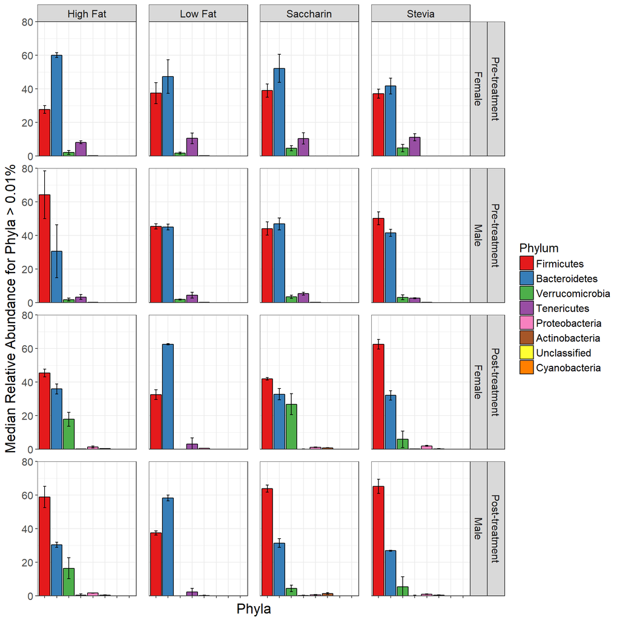

Sex-related trends that caught my eye (not statistically tested yet):

- Pre-treatment females generally have a higher % Bacteroidetes compared to males
  - Especially in High Fat Pre-treatment
- Saccharin Post-treatment
  - Females have higher % Verrucomicrobia compared to males

# Within-Sample Diversity (Alpha)

## Chao Richness

Chao is an estimate of richness (# unique OTUs exist in a particular sample).

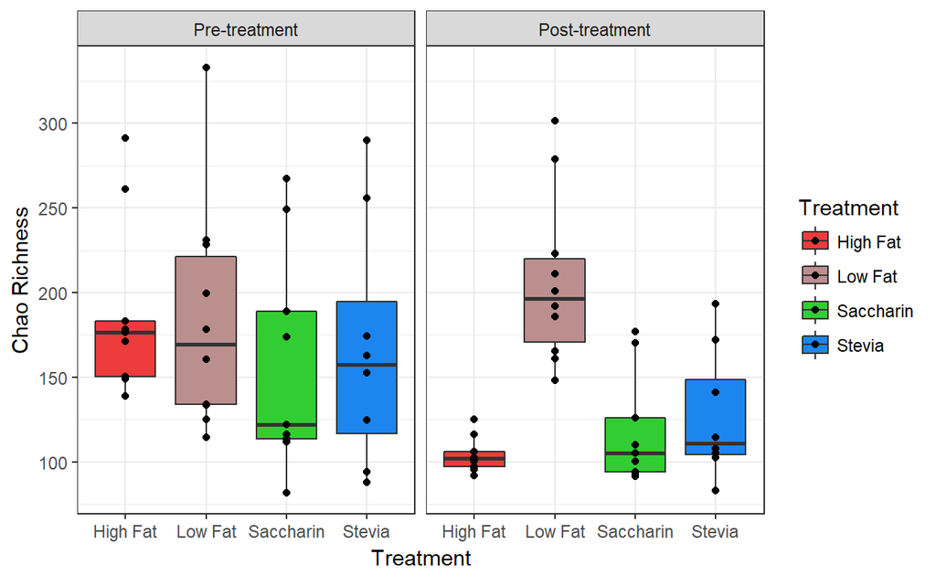

- Post-treatment groups are significantly different (adj p-val = 0.004). Specifically:
  - High Fat vs. Low Fat
  - Low Fat vs. Saccharin
- High Fat Pre-treatment and Post-treatment are significantly different (adj p-val = 0.018)

## Shannon Diversity

Shannon’s Index is an estimate of diversity, taking into account both the presence/absence and abundance of OTUs.

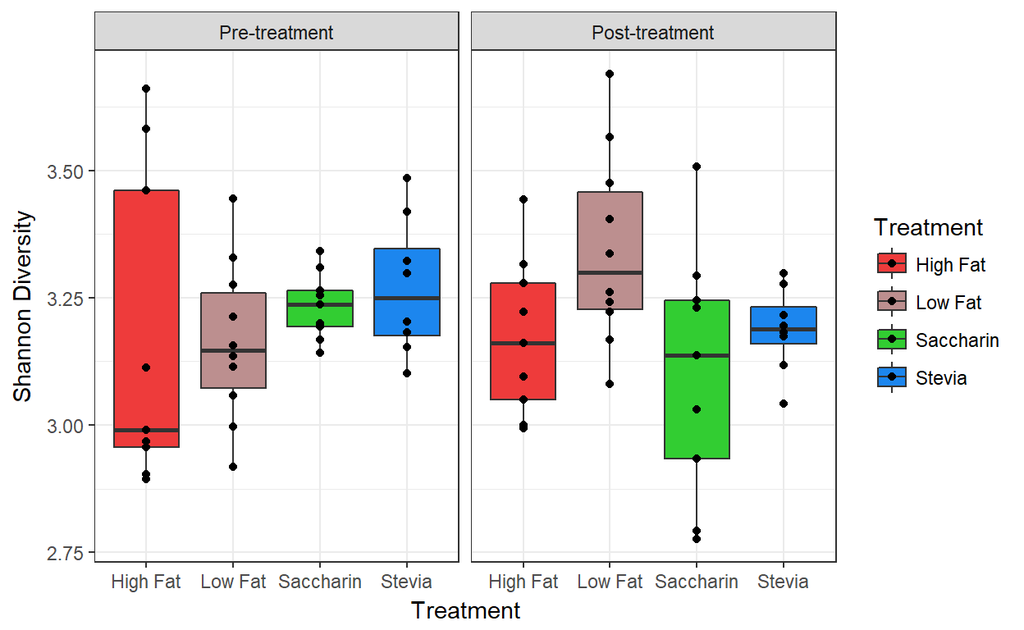

No significant differences.  
This suggests that differences in within-sample diversity are driven by presence/absence of OTUs rather than their relative abundances.

# Between-Sample Diversity (Beta)

I used the Bray-Curtis dissimilarity metric, which considers both OTU presence/absence and weight (abundance).

In the ordination, each point is 1 sample. The distance betwen points is inversely related to how similar the samples are.  
Closer points = more similar.  
Farther points = less similar.

## Overall

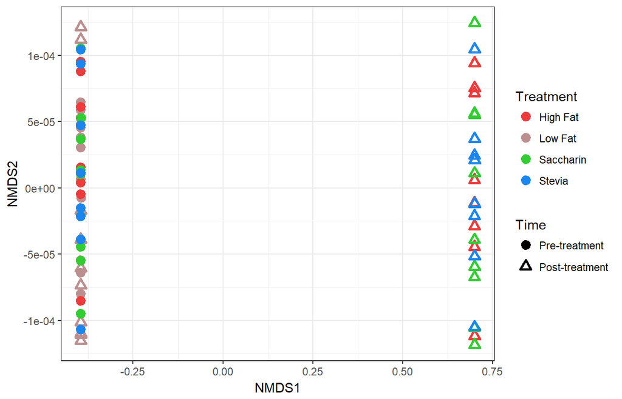

Pre-treatment vs. Post-treatment samples visually cluster distinctly for all samples except Low Fat.  
Within each treatment, Pre vs. Post are significantly different (all adj pvals = 0.005).

To determine to what extent the categorical factors contribute to between-sample differences, I used PERMANOVA to evaluate:

- Time
  - Pre-treatment vs. Post-treatment
- Treatment
  - High Fat, Low Fat, Saccharin, Stevia
- Sex
  - Female, Male
- Individual
  - My attempt to account for the paired nature of the data

| Factor | pval | R2 |
| --- | --- | --- |
| Time | 0.001 | 0.258 |
| Treatment | 0.001 | 0.123 |
| Sex | 0.001 | 0.074 |
| Individual | 0.907 | 0.230 |
| Residual | NA | 0.349 |

- Time accounts for the most variation in the data, followed by Treatment and Sex
- Individual accounted for quite a bit of the data variation, but was not significant (likely because we have a small n (2) for each individual)

## Pre-treatment

Given that time explains the most data variation, let’s take a look within Pre-treatment samples:

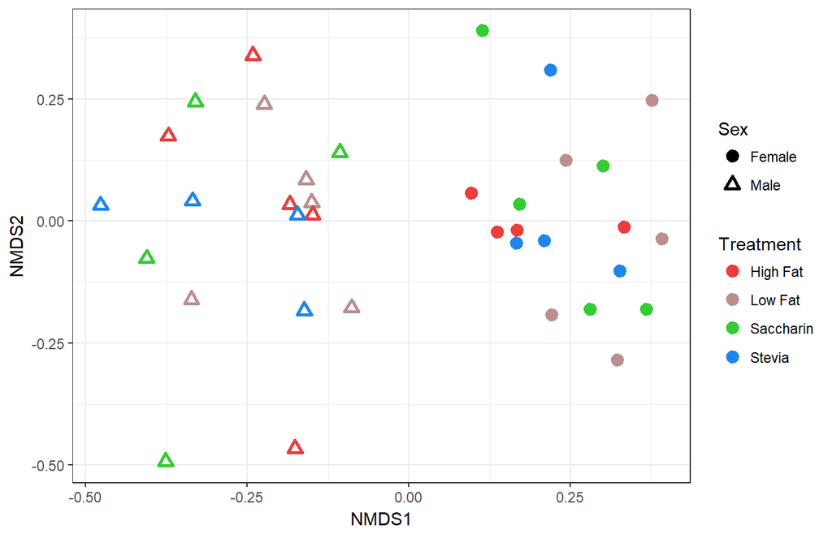

- There is no significance between treatments.
- There *is* a significant difference between sex (adj pval = 0.005).

## Post-treatment

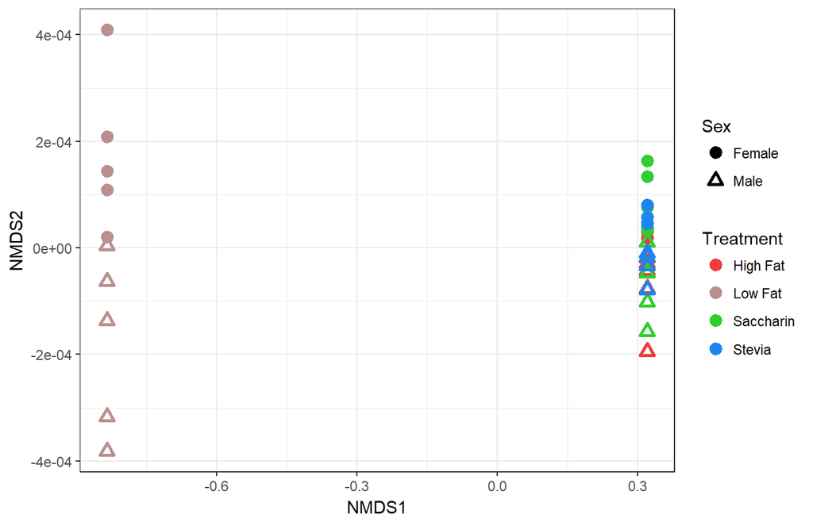

- Unlike in Pre-treatment samples, sex is not significant in Post-treatment samples (adj p-val = 0.326)
- Low Fat is significantly different from all other treatments (all adj pvals = 0.005)
  - This is true overall, and within sex
- Saccharin vs. Stevia trend towards a difference (adj pval = 0.063)
  - This trend is seen within Females (adj pval = 0.063), but not within Males (adj pval = 0.571)

# Important OTUs

I identified the OTUs that contribute the most to variation in between-sample diversity using pairwise comparisons. These OTUs are the most abundant and/or variable in the samples.  
This test (similarity percentages (SIMPER)) is run with pairwise comparisons.

## Post-treatment

### Low Fat vs. Other Treatments

The difference between Low Fat vs. other treatments is driven by the following number of OTUs:

- High Fat = 8
- Saccharin = 7
- Stevia = 9

All the identified OTUs within 1 pairwise comparison (Low Fat vs. 1 treatment) are found in at least 1 other pairwise comparison (Low Fat vs. another treatment).

| Compared Treatment | Variation Explained (%) | Adj Pval | Phylum | Class | Order | Family | Genus | OTU | Low Fat Rel Abund (%) | Compared Treatment Rel Abund (%) |
| --- | --- | --- | --- | --- | --- | --- | --- | --- | --- | --- |
| High Fat | 4.03 | 0.000071 | Bacteroidetes | Bacteroidia | Bacteroidales | S24-7 | Unclassified | OTU 14 | 0.00 | 6.45 |
| High Fat | 5.76 | 0.000200 | Bacteroidetes | Bacteroidia | Bacteroidales | Bacteroidaceae | Bacteroides | OTU 4 | 1.22 | 10.44 |
| High Fat | 4.50 | 0.000200 | Bacteroidetes | Bacteroidia | Bacteroidales | S24-7 | Unclassified | OTU 12 | 0.37 | 7.57 |
| High Fat | 3.26 | 0.000200 | Tenericutes | Mollicutes | Anaeroplasmatales | Anaeroplasmataceae | Anaeroplasma | OTU 10 | 0.81 | 6.03 |
| High Fat | 2.48 | 0.000300 | Bacteroidetes | Bacteroidia | Bacteroidales | S24-7 | Unclassified | OTU 8 | 3.97 | 0.00 |
| High Fat | 8.24 | 0.004000 | Bacteroidetes | Bacteroidia | Bacteroidales | S24-7 | Unclassified | OTU 2 | 0.19 | 13.29 |
| High Fat | 4.71 | 0.006200 | Bacteroidetes | Bacteroidia | Bacteroidales | S24-7 | Unclassified | OTU 23 | 7.92 | 0.70 |
| High Fat | 2.39 | 0.007100 | Firmicutes | Clostridia | Clostridiales | Ruminococcaceae | Ruminiclostridium | OTU 3 | 3.39 | 6.77 |
| Saccharin | 9.57 | 0.095700 | Firmicutes | Clostridia | Clostridiales | Lachnospiraceae | Unclassified | OTU 2 | 0.19 | 15.33 |
| Saccharin | 3.58 | 0.035800 | Firmicutes | Clostridia | Clostridiales | Ruminococcaceae | Ruminiclostridium | OTU 10 | 0.81 | 6.48 |
| Saccharin | 2.50 | 0.025000 | Firmicutes | Clostridia | Clostridiales | Lachnospiraceae | Unclassified | OTU 8 | 3.97 | 0.01 |
| Saccharin | 3.98 | 0.039800 | Firmicutes | Clostridia | Clostridiales | vadinBB60 | Unclassified | OTU 12 | 0.37 | 6.64 |
| Saccharin | 2.08 | 0.020800 | Firmicutes | Clostridia | Clostridiales | Lachnospiraceae | NK4A136 | OTU 21 | 3.30 | 0.01 |
| Saccharin | 5.74 | 0.057400 | Firmicutes | Clostridia | Clostridiales | Lachnospiraceae | NK4A136 | OTU 4 | 1.22 | 10.04 |
| Saccharin | 4.77 | 0.047700 | Firmicutes | Clostridia | Clostridiales | Ruminococcaceae | Oscillibacter | OTU 23 | 7.92 | 6.28 |
| Stevia | 5.44 | 0.054400 | Firmicutes | Clostridia | Clostridiales | Lachnospiraceae | Unclassified | OTU 14 | 0.00 | 8.71 |
| Stevia | 4.72 | 0.047200 | Firmicutes | Clostridia | Clostridiales | Lachnospiraceae | NK4A136 | OTU 4 | 1.22 | 8.78 |
| Stevia | 4.63 | 0.046300 | Firmicutes | Clostridia | Clostridiales | Ruminococcaceae | Unclassified | OTU 12 | 0.37 | 7.77 |
| Stevia | 4.28 | 0.042800 | Bacteroidetes | Bacteroidia | Bacteroidales | S24-7 | Unclassified | OTU 10 | 0.81 | 7.67 |
| Stevia | 4.34 | 0.043300 | Firmicutes | Clostridia | Clostridiales | Lachnospiraceae | NK4A136 | OTU 2 | 0.19 | 7.04 |
| Stevia | 2.47 | 0.024700 | Firmicutes | Clostridia | Clostridiales | Lachnospiraceae | NK4A136 | OTU 8 | 3.97 | 0.01 |
| Stevia | 2.07 | 0.020700 | Proteobacteria | Betaproteobacteria | Burkholderiales | Alcaligenaceae | Parasutterella | OTU 21 | 3.30 | 0.00 |
| Stevia | 4.82 | 0.048200 | Firmicutes | Clostridia | Clostridiales | Lachnospiraceae | Unclassified | OTU 23 | 7.92 | 0.39 |
| Stevia | 2.12 | 0.021200 | Firmicutes | Clostridia | Clostridiales | Lachnospiraceae | Unclassified | OTU 3 | 3.38 | 6.29 |

### High Fat vs. Saccharin

| Variation Explained (%) | Adj Pval | Phylum | Class | Order | Family | Genus | OTU | High Fat Rel Abund (%) | Saccharin Rel Abund (%) |
| --- | --- | --- | --- | --- | --- | --- | --- | --- | --- |
| 4.05 | 0.0638 | Firmicutes | Clostridia | Clostridiales | Lachnospiraceae | Unclassified | OTU 14 | 6.45 | 3.18 |

### Saccharin vs. Stevia

| Variation Explained (%) | Adj Pval | Phylum | Class | Order | Family | Genus | OTU | Saccharin Rel Abund (%) | Stevia Rel Abund (%) |
| --- | --- | --- | --- | --- | --- | --- | --- | --- | --- |
| 6.19 | 0.0043 | Firmicutes | Clostridia | Clostridiales | Lachnospiraceae | Lachnoclostridium | OTU 14 | 3.18 | 8.71 |

## High Fat

#### Pre-treatment vs. Post-treatment

| Variation Explained (%) | Adj Pval | Phylum | Class | Order | Family | Genus | OTU | Pre Rel Abund (%) | Post Rel Abund (%) |
| --- | --- | --- | --- | --- | --- | --- | --- | --- | --- |
| 4.91 | 0.0017 | Bacteroidetes | Bacteroidia | Bacteroidales | Bacteroidiaceae | Unclassified | OTU 5 | 8.390 | 0.81 |
| 4.69 | 0.0036 | Bacteroidetes | Bacteroidia | Bacteroidales | S24-7 | Unclassified | OTU 12 | 0.025 | 7.57 |
| 4.13 | 0.0021 | Bacteroidetes | Bacteroidia | Bacteroidales | S24-7 | Unclassified | OTU 14 | 0.000 | 6.45 |
| 3.49 | 0.0125 | Bacteroidetes | Bacteroidia | Bacteroidales | S24-7 | Unclassified | OTU4 | 5.170 | 10.44 |
| 3.25 | 0.0036 | Firmicutes | Clostridia | Clostridiales | Ruminococcaceae | Ruminiclostridium | OTU 10 | 0.960 | 6.03 |
| 2.42 | 0.0040 | Bacteroidetes | Bacteroidia | Bacteroidales | S24-7 | Unclassified | OTU 15 | 0.380 | 0.00 |

## Low Fat

#### Pre-treatment vs. Post-treatment

| Variation Explained (%) | Adj Pval | Phylum | Class | Order | Family | Genus | OTU | Pre Rel Abund (%) | Post Rel Abund (%) |
| --- | --- | --- | --- | --- | --- | --- | --- | --- | --- |
| 5.83 | 0.0092 | Bacteroidetes | Bacteroidia | Bacteroidales | Bacteroidaceae | Bacteroides | OTU 23 | 0.61 | 7.92 |
| 3.21 | 0.0337 | Tenericutes | Mollicutes | Anaeroplasmatales | Anaeroplasmataceae | Anaeroplasma | OTU 3 | 7.11 | 3.38 |
| 3.00 | 0.0139 | Firmicutes | Clostridia | Clostridiales | Ruminococcaceae | Ruminiclostridium | OTU 15 | 4.49 | 0.85 |

## Saccharin

#### Pre-treatment vs. Post-treatment

| Variation Explained (%) | Adj Pval | Phylum | Class | Order | Family | Genus | OTU | Pre Rel Abund (%) | Post Rel Abund (%) |
| --- | --- | --- | --- | --- | --- | --- | --- | --- | --- |
| 7.12 | 0.0125 | Verrucomicrobia | Verrucomicrobiae | Verrucomicrobiales | Verrucomicrobiaceae | Akkermansia | OTU 5 | 11.50 | 0.77 |
| 4.52 | 0.0247 | Bacteroidetes | Bacteroidia | S24-7 | Unclassified | Unclassified | OTU 4 | 4.10 | 10.04 |
| 4.22 | 0.0051 | Bacteroidetes | Bacteroidia | S24-7 | Unclassified | Unclassified | OTU 12 | 0.24 | 6.64 |
| 3.48 | 0.0056 | Bacteroidetes | Bacteroidia | S24-7 | Unclassified | Unclassified | OTU 8 | 5.32 | 0.01 |
| 3.16 | 0.0071 | Tenericutes | Mollicutes | Anaeroplasmatales | Anaeroplasmataceae | Anaeroplasma | OTU 10 | 1.84 | 6.48 |

## Stevia

#### Pre-treatment vs. Post-treatment

| Variation Explained (%) | Adj Pval | Phylum | Class | Order | Family | Genus | OTU | Pre Rel Abund (%) | Post Rel Abund (%) |
| --- | --- | --- | --- | --- | --- | --- | --- | --- | --- |
| 5.62 | 0.0036 | Bacteroidetes | Bacteroidia | Bacteroidales | S24-7 | Unclassified | OTU 14 | 0.00 | 8.71 |
| 4.89 | 0.0049 | Bacteroidetes | Bacteroidia | Bacteroidales | Bacteroidaceae | Bacteroides | OTU 12 | 0.19 | 7.77 |
| 4.40 | 0.0139 | Bacteroidetes | Bacteroidia | Bacteroidales | S24-7 | Unclassified | OTU 5 | 7.34 | 0.53 |
| 4.18 | 0.0056 | Bacteroidetes | Bacteroidia | Bacteroidales | S24-7 | Unclassified | OTU 10 | 1.21 | 7.67 |
| 3.68 | 0.0043 | Bacteroidetes | Bacteroidia | Bacteroidales | S24-7 | Unclassified | OTU 8 | 5.75 | 0.01 |
| 3.40 | 0.0125 | Firmicutes | Clostridia | Clostridiales | Ruminococcaceae | Ruminiclostridium | OTU 4 | 3.58 | 8.78 |

## Male vs. Female

These results are for Pre-treatment only.  
No OTUs were detected within Post-treatment samples overall.

| Variation Explained (%) | Adj Pval | Phylum | Class | Order | Family | Genus | OTU | Female Rel Abund (%) | Male Rel Abund (%) |
| --- | --- | --- | --- | --- | --- | --- | --- | --- | --- |
| 9.74 | 5.30e-06 | Firmicutes | Clostridia | Clostridiales | Ruminococcaceae | Ruminiclostridium | OTU 6 | 12.34 | 0.01 |
| 7.97 | 3.77e-05 | Bacteroidetes | Bacteroidia | Bactteroidales | S24-7 | Unclassified | OTU 13 | 0.17 | 10.22 |
| 7.06 | 7.50e-03 | Firmicutes | Clostridia | Clostridiales | Lachnospiraceae | Unclassified | OTU 5 | 3.86 | 11.42 |
| 5.85 | 2.00e-04 | Firmicutes | Erysipelotrichia | Erysipelotrichales | Erysipelotrichaceae | Unclassified | OTU 11 | 8.14 | 1.44 |
| 5.58 | 1.00e-04 | Firmicutes | Clostridia | Clostridiales | Lachnospiraceae | Tyzzerella | OTU 8 | 9.18 | 2.29 |